# Assignment 1 - Partial Least Squares

Kevin Patyk, Michael Koch, & Sander van Gestel

11/29/2021

# Loading libraries

```r
library(tidyverse)
library(pls)
library(glmnet)
```

# Loading and inspecting the data

Importing the `corn.rds` data.

```r
corn <- read_rds("corn.rds")
```

Examining the first 6 observations.

```r
head(corn)
```

```
## # A tibble: 6 x 704
##   Moisture   Oil Protein Starch  `1100`  `1102`  `1104`  `1106`  `1108`  `1110`
##      <dbl> <dbl>   <dbl>  <dbl>   <dbl>   <dbl>   <dbl>   <dbl>   <dbl>   <dbl>
## 1     10.4  3.69    8.75   64.8 -0.0227 -0.0228 -0.0229 -0.0229 -0.0229 -0.0228
## 2     10.4  3.72    8.66   64.9 -0.0219 -0.0221 -0.0222 -0.0222 -0.0222 -0.0222
## 3     10.3  3.50    9.12   63.6 -0.0209 -0.0210 -0.0211 -0.0212 -0.0212 -0.0212
## 4     10.3  3.50    9.39   63.3 -0.0236 -0.0238 -0.0239 -0.0239 -0.0239 -0.0239
## 5     10.3  3.66    8.95   64.1 -0.0152 -0.0153 -0.0154 -0.0155 -0.0155 -0.0155
## 6     10.3  3.51    8.73   64.3 -0.0157 -0.0159 -0.0160 -0.0160 -0.0160 -0.0160
## # ... with 694 more variables: 1112 <dbl>, 1114 <dbl>, 1116 <dbl>, 1118 <dbl>,
## #   1120 <dbl>, 1122 <dbl>, 1124 <dbl>, 1126 <dbl>, 1128 <dbl>, 1130 <dbl>,
## #   1132 <dbl>, 1134 <dbl>, 1136 <dbl>, 1138 <dbl>, 1140 <dbl>, 1142 <dbl>,
## #   1144 <dbl>, 1146 <dbl>, 1148 <dbl>, 1150 <dbl>, 1152 <dbl>, 1154 <dbl>,
## #   1156 <dbl>, 1158 <dbl>, 1160 <dbl>, 1162 <dbl>, 1164 <dbl>, 1166 <dbl>,
## #   1168 <dbl>, 1170 <dbl>, 1172 <dbl>, 1174 <dbl>, 1176 <dbl>, 1178 <dbl>,
## #   1180 <dbl>, 1182 <dbl>, 1184 <dbl>, 1186 <dbl>, 1188 <dbl>, 1190 <dbl>, ...
```

Getting the number of rows and columns.

```r
dim(corn)
```

```
## [1]  80 704
```

# Conducting the analysis

**1: Pick a property (`Moisture`, `Oil`, `Starch`, or `Protein`) to predict.**

```r
outcome <- corn$Moisture
```

**2: Split your data into a training (80%) and test (20%) set.**

```r
#splitting the training and testing data
set.seed(45)
corn$splits <- sample(rep(c("train", "test"), times = c(64, 16)))

corn_train <- corn %>%
  filter(splits == "train") %>%
  select(-c(splits, Oil, Starch, Protein))

corn_test <- corn %>%
  filter(splits == "test") %>%
  select(-c(splits, Oil, Starch, Protein))
```

**3: Use the function `plsr` from the package `pls` to estimate a partial least squares model, predicting the property using the NIR spectroscopy measurements in the training data. Make sure that the features are on the same scale. Use leave-one-out cross-validation (built into `plsr`) to estimate out-of-sample performance.**

```r
mod_1 <- plsr(Moisture ~ ., center = T, scale = T, validation = "LOO", data = corn_train)
```

**4: Find out which component best predicts the property you chose. Explain how you did this.**

```r
#getting a summary of the model
summary(mod_1)
```

```
## Data:    X dimension: 64 700
##  Y dimension: 64 1
## Fit method: kernelpls
## Number of components considered: 62
##
## VALIDATION: RMSEP
## Cross-validated using 64 leave-one-out segments.
##        (Intercept)  1 comps  2 comps  3 comps  4 comps  5 comps  6 comps
## CV          0.4008   0.3281   0.2791   0.2497   0.2255   0.2110   0.1961
## adjCV       0.4008   0.3280   0.2790   0.2496   0.2254   0.2108   0.1960
##        7 comps  8 comps  9 comps  10 comps  11 comps  12 comps  13 comps
## CV      0.1768   0.1618   0.1569    0.1616    0.1582    0.1585    0.1602
## adjCV   0.1766   0.1616   0.1566    0.1612    0.1578    0.1581    0.1597
##        14 comps  15 comps  16 comps  17 comps  18 comps  19 comps  20 comps
## CV       0.1560    0.1591    0.1489    0.1467    0.1392    0.1447    0.1386
## adjCV    0.1555    0.1584    0.1482    0.1460    0.1386    0.1441    0.1380
##        21 comps  22 comps  23 comps  24 comps  25 comps  26 comps  27 comps
## CV       0.1356    0.1328    0.1340    0.1335    0.1323    0.1326    0.1386
## adjCV    0.1350    0.1321    0.1332    0.1327    0.1316    0.1318    0.1376
##        28 comps  29 comps  30 comps  31 comps  32 comps  33 comps  34 comps
## CV       0.1417    0.1448    0.1509    0.1532    0.1519    0.1520    0.1505
## adjCV    0.1408    0.1439    0.1498    0.1521    0.1508    0.1508    0.1494
##        35 comps  36 comps  37 comps  38 comps  39 comps  40 comps  41 comps
## CV       0.1485    0.1480    0.1464    0.1458    0.1456    0.1456    0.1455
## adjCV    0.1474    0.1469    0.1453    0.1447    0.1444    0.1444    0.1444
##        42 comps  43 comps  44 comps  45 comps  46 comps  47 comps  48 comps
## CV       0.1456    0.1455    0.1455    0.1455    0.1455    0.1455    0.1455
## adjCV    0.1444    0.1444    0.1443    0.1443    0.1443    0.1443    0.1443
##        49 comps  50 comps  51 comps  52 comps  53 comps  54 comps  55 comps
## CV       0.1455    0.1455    0.1455    0.1455    0.1455    0.1455    0.1455
## adjCV    0.1443    0.1443    0.1443    0.1443    0.1443    0.1443    0.1443
##        56 comps  57 comps  58 comps  59 comps  60 comps  61 comps  62 comps
## CV       0.1455    0.1455    0.1455    0.1455    0.1455    0.1455    0.1455
## adjCV    0.1443    0.1443    0.1443    0.1443    0.1443    0.1443    0.1443
##
## TRAINING: % variance explained
##           1 comps  2 comps  3 comps  4 comps  5 comps  6 comps  7 comps
## X           98.09    99.55    99.84    99.91    99.95    99.97    99.99
## Moisture    34.89    54.81    65.43    74.18    78.80    82.66    86.49
##           8 comps  9 comps  10 comps  11 comps  12 comps  13 comps  14 comps
```

[output cut: 8 more lines]

```
##           29 comps  30 comps  31 comps  32 comps  33 comps  34 comps  35 comps
## X           100.00    100.00    100.00    100.00    100.00    100.00    100.00
## Moisture     99.73     99.83     99.89     99.94     99.97     99.99     99.99
##           36 comps  37 comps  38 comps  39 comps  40 comps  41 comps  42 comps
## X              100       100       100       100       100       100       100
## Moisture       100       100       100       100       100       100       100
##           43 comps  44 comps  45 comps  46 comps  47 comps  48 comps  49 comps
## X              100       100       100       100       100       100       100
## Moisture       100       100       100       100       100       100       100
##           50 comps  51 comps  52 comps  53 comps  54 comps  55 comps  56 comps
## X              100       100       100       100       100       100       100
## Moisture       100       100       100       100       100       100       100
##           57 comps  58 comps  59 comps  60 comps  61 comps  62 comps
## X              100       100       100       100       100       100
## Moisture       100       100       100       100       100       100
```

According to the output, the first component best predicts the outcome that we chose (`Moisture`). This is because the first component explains 34.89% of the variance in `Moisture`, with each subsequent component explaining less and less variation in `Moisture`. This makes sense since the first component maximizes the covariance between `x` and `y`.

**5: Create a plot with on the x-axis the wavelength, and on the y-axis the strength of the loading for this component. Explain which wavelengths are most important for predicting the property you are interested in.**

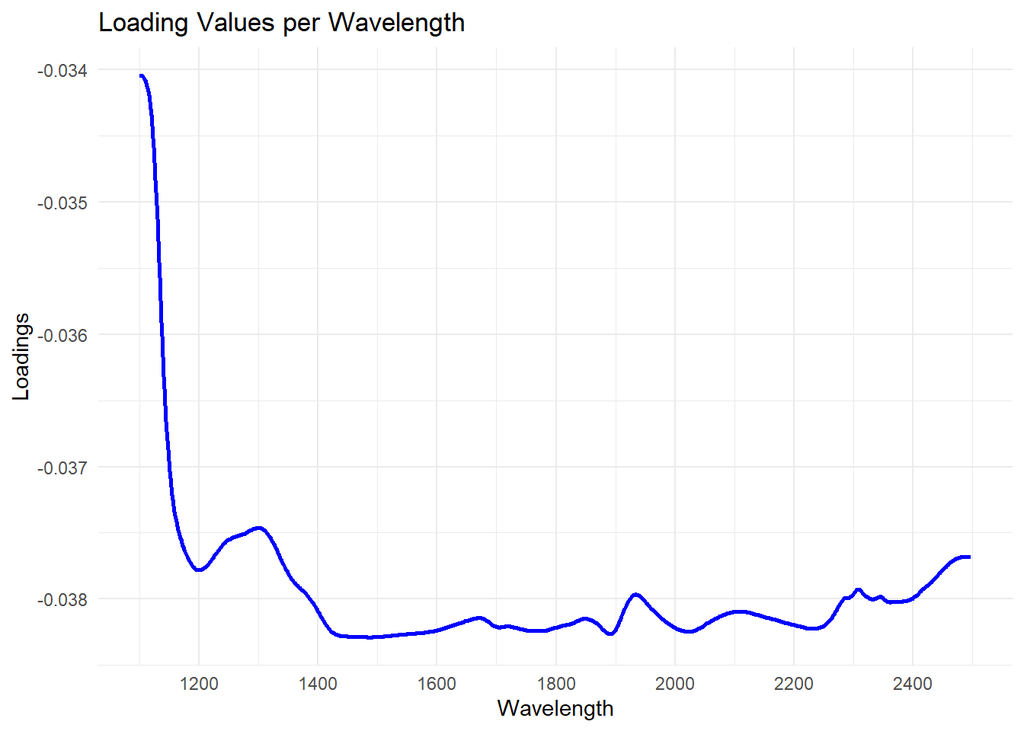

```r
#creating a separate dating frame for the loading info
load_info <- data.frame(
  "Loadings" = mod_1$loadings[1:700],
  "Wavelength" = seq(1100, 2498, 2))

#creating a plot
load_info %>%
  ggplot(aes(x = Wavelength, y = Loadings)) +
  geom_line(size = 1, color = "blue") +
  labs(title = "Loading Values per Wavelength") +
  scale_x_continuous(n.breaks = 10) +
  theme_minimal()
```

In the plot it can be seen that wavelengths between 1400 and 1600 have the strongest loadings. Therefore wavelengths between 1400 and 1600 seem to be the most important in predicting the outcome `Moisture`.

**6: Pick the number of components included in the model based on the “one standard deviation” rule (`selectNcomp()`). Create predictions for the test set using the resulting model.**

```r
#selecting the number of components based on the one standard deviation rule
selectNcomp(mod_1, method = "onesigma")
```

```
## [1] 16
```

```r
#creating predictions using the one standard deviation rules
pcr_pred_2 <- predict(mod_1, corn_test, ncomp = 1:16)

#calculating the mse for the model
mse_pls <- mean((pcr_pred_2 - corn_test$Moisture)^2)
```

**7: Compare your PLS predictions to a LASSO linear regression model where lambda is selected based on cross-validation with the one standard deviation rule (using `cv.glmnet`).**

```r
#training sets
x_train <- corn_train %>% as.matrix()
y_train <- corn_train %>% pull(Moisture)

#testing sets
x_test <- corn_test %>% as.matrix()
y_test <- corn_test %>% pull(Moisture)

#running the lasso linear regression model
mod_2 <- cv.glmnet(x = x_train, # X matrix without intercept
                   y = y_train, # Salary as response
                   family = "gaussian", # Normally distributed errors
                   alpha = 1, # LASSO Penalty
                   nfolds = 10)

#creating predictions using the test set
pred_mod_2 <- predict(mod_2, newx = x_test, s = "lambda.min")

#calculating the mse for the model
mse_lasso <- mean((pred_mod_2  - y_test)^2)

#mse values
mse_pls
```

```
## [1] 0.02492679
```

```r
mse_lasso
```

```
## [1] 8.576254e-05
```

```r
#pls mse vs lasso
mse_pls < mse_lasso
```

```
## [1] FALSE
```

The LASSO linear regression model has a lower out-of-sample MSE and performs better than the PLS regression model.